# Плохие и хорошие данные

## Продукты литературного программирования

## Виды “литературных” продуктов

- Тексты (статьи, монографии, отчеты, главы Летописи природы)
- Презентации (Power Point, HTML-презентации, LaTex-презентации)
- Страницы интернет-сайтов с динамически меняющейся информацией (например, каталоги магазинов).

## Структура продукта

Документ состоит из текста и вставленных в текст объектов (результатов обработки данных, иллюстрации).

**Текст**  
- Заголовки разных уровней.  
- Абзацы (параграфы), состоящие из нескольких предложений. - Сноски - Специальные символы и формулы.

**Иллюстрации** - Изображения, которые не являются результатами обработки, выполненной с помощью программного кода, написанного автором документа (Фотографии, карты, штриховые рисунки и т.п.)

**Результаты обработки данных** - Визуализации результатов обработки данных (диаграммы, графики и т.п.). - Таблицы - Числовые значения в тексте - Библиографические описания

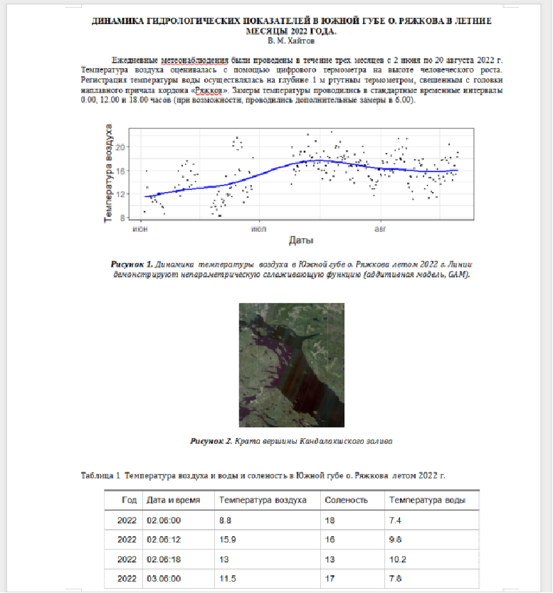

## Общая схема литературного программирования

[figure not shown]

## Данные

## Исходные данные часто приходится приводить в порядок

На подготовку данных к анализу уходит до 80% времени.

Существуют определенные правила предоставления данных.

Данные, построенные в соответствии с этими требованиями, называются **tidy data**, или **опрятные данные**.

## Проблемы начинаются уже в электронных таблицах

[figure not shown]

## Основные ошибки

- **Объединенные ячейки**
- Отсутствующие заголовки столбцов, вместо них стоят какие-то числа (или ничего не стоит) или слишком длинные имена заголовков
- В одной ячейке находится сразу несколько значений
- Разнородные данные в пределах одного столбца
- Нет стандартного обозначения пропущенных значений
- Разные группы значений кодируются цветовыми выделениями
- Вместе с первичными данными приведены результаты их обработки (подсчитаны средние, суммы и т.п.)

## Принятые нормы

- Столбцы - переменные (variables)
- Строки - объекты (observations)
- В каждой переменной только один тип данных
- На месте пропущенных значений стоит специальный знак (в R принят `NA`)

**При работе в Excel не должно быть никаких объединенных ячеек!**

## Два формата представления данных

- Широкий формат: данные максимально структурированы, каждая строка может нести информацию о многих элементарных объектах
- Длинный формат: данные минимально структурированы, каждая строка характеризует уникальный объект

Из длинного формата легко получить широкий.

Из широкого формата получить длинный заметно сложнее.

Широкий формат хорош для отчетов, представления обобщенных результатов

Длинный формат хорош для анализа

## В каком формате представлены данные?

```
##    Class    Sex   Age Survived Freq
## 1    1st   Male Child       No    0
## 2    2nd   Male Child       No    0
## 3    3rd   Male Child       No   35
## 4   Crew   Male Child       No    0
## 5    1st Female Child       No    0
## 6    2nd Female Child       No    0
## 7    3rd Female Child       No   17
## 8   Crew Female Child       No    0
## 9    1st   Male Adult       No  118
## 10   2nd   Male Adult       No  154
## 11   3rd   Male Adult       No  387
## 12  Crew   Male Adult       No  670
## 13   1st Female Adult       No    4
## 14   2nd Female Adult       No   13
## 15   3rd Female Adult       No   89
## 16  Crew Female Adult       No    3
## 17   1st   Male Child      Yes    5
## 18   2nd   Male Child      Yes   11
## 19   3rd   Male Child      Yes   13
## 20  Crew   Male Child      Yes    0
```

## Длинный формат данных

```
##    Class  Sex   Age Survived
## 1    3rd Male Child       No
## 2    3rd Male Child       No
## 3    3rd Male Child       No
## 4    3rd Male Child       No
## 5    3rd Male Child       No
## 6    3rd Male Child       No
## 7    3rd Male Child       No
## 8    3rd Male Child       No
## 9    3rd Male Child       No
## 10   3rd Male Child       No
## 11   3rd Male Child       No
## 12   3rd Male Child       No
## 13   3rd Male Child       No
## 14   3rd Male Child       No
## 15   3rd Male Child       No
## 16   3rd Male Child       No
## 17   3rd Male Child       No
## 18   3rd Male Child       No
## 19   3rd Male Child       No
## 20   3rd Male Child       No
```

## Take home message

- Документ - это комбинация текста, иллюстраций и производных анализа данных.
- Первичные данные должны быть оформлены, как опрятные данные (tidy data).
- При работе в электронных таблицах (Excel) надо соблюдать правила опрятных данных.
- Первичные данные могут быть представлены в широком и длинном форматах.
- Для обработки удобнее использовать длинный формат.